# Популяционная структура

## Динамика размерной структуры

Строим модель, отражающую многолетнюю и сезонную динамику размера рыб.

Вот ее резeльтирующие данные.

```
##
## Family: gaussian
## Link function: identity
##
## Formula:
## L ~ s(Year) + s(DOY)
##
## Parametric coefficients:
##             Estimate Std. Error t value Pr(>|t|)
## (Intercept)  32.5869     0.1114   292.5   <2e-16 ***
## ---
## Signif. codes:  0 '***' 0.001 '**' 0.01 '*' 0.05 '.' 0.1 ' ' 1
##
## Approximate significance of smooth terms:
##           edf Ref.df     F p-value
## s(Year) 7.011  8.015 5.712  <2e-16 ***
## s(DOY)  7.060  8.074 1.705  0.0827 .
## ---
## Signif. codes:  0 '***' 0.001 '**' 0.01 '*' 0.05 '.' 0.1 ' ' 1
##
## R-sq.(adj) =  0.0312   Deviance explained =  3.8%
## GCV = 25.169  Scale est. = 24.98     n = 2013
```

Есть статистически значимая многолетняя динамика размеров.

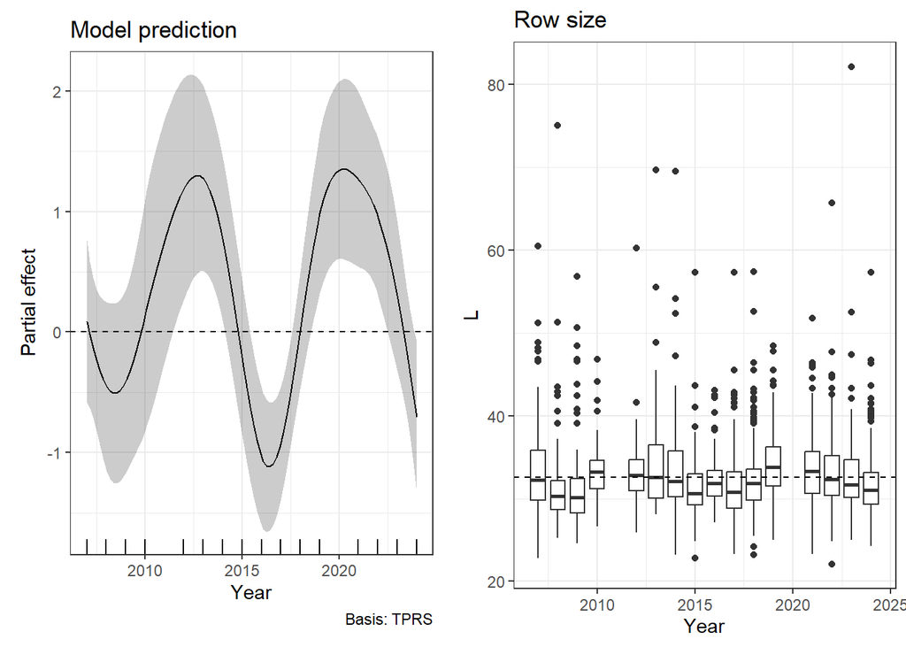

Были два периода, когда размер был выше многолетней средней. Может подходы баренцевоморской трески? Я помню годы, когда ловились большие особи нетипично красного цвета. Или может меняли размер ячеи на сетках?

## Динамика полового состава

Построил модель, отражающую одновременно многолетнюю и сезонную динамику полового состава (доля самок).

Вот формула модели:

Sex ~ s(Year) + s(DOY)

Вот ее результат

```
##
## Family: binomial
## Link function: logit
##
## Formula:
## Sex2 ~ s(Year) + s(DOY)
##
## Parametric coefficients:
##             Estimate Std. Error z value Pr(>|z|)
## (Intercept)  0.70476    0.05957   11.83   <2e-16 ***
## ---
## Signif. codes:  0 '***' 0.001 '**' 0.01 '*' 0.05 '.' 0.1 ' ' 1
##
## Approximate significance of smooth terms:
##           edf Ref.df Chi.sq p-value
## s(Year) 3.605  4.408 12.429  0.0191 *
## s(DOY)  3.654  4.526  7.833  0.1605
## ---
## Signif. codes:  0 '***' 0.001 '**' 0.01 '*' 0.05 '.' 0.1 ' ' 1
##
## R-sq.(adj) =  0.0147   Deviance explained = 1.61%
## UBRE = 0.26499  Scale est. = 1         n = 1294
```

Сезонной динамики встречаемости нет, но есть значимая многолетня динамика.

Вот визуализация.

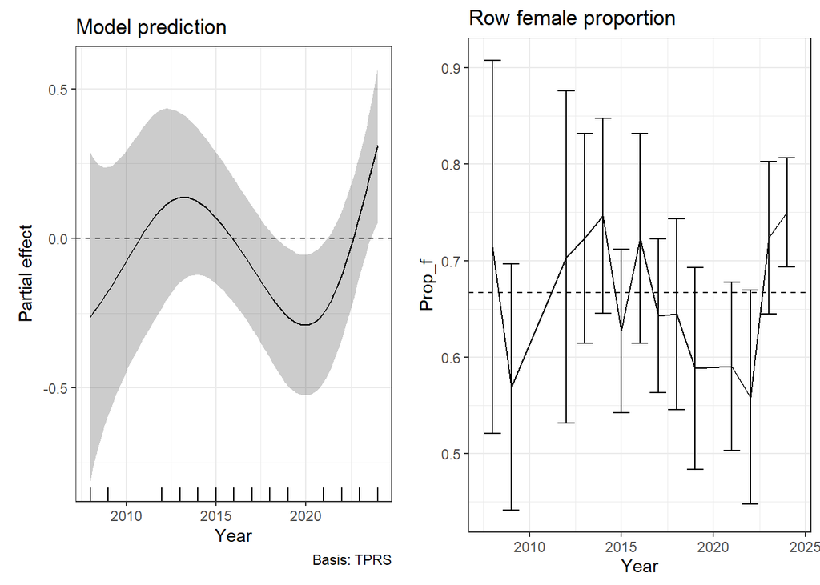

Видно, что был какой-то провал в частоте самок, за которым их доля выросла выше многолетней популяционной среденей, которая равна 0.67.

# Общее описание рациона

## Динамика пустых желудков

Модель, котрую строим имеет следующий вид

Empty ~ s(Year) + s(DOY) + s(L), data = total_weight, family = “binomial”

Вот результаты подбора модели

```
##
## Family: binomial
## Link function: logit
##
## Formula:
## Empty ~ s(Year) + s(DOY) + s(L)
##
## Parametric coefficients:
##             Estimate Std. Error z value Pr(>|z|)
## (Intercept) -1.16228    0.05433  -21.39   <2e-16 ***
## ---
## Signif. codes:  0 '***' 0.001 '**' 0.01 '*' 0.05 '.' 0.1 ' ' 1
##
## Approximate significance of smooth terms:
##           edf Ref.df Chi.sq  p-value
## s(Year) 7.761  8.571 41.276 1.81e-06 ***
## s(DOY)  6.864  7.913 65.044  < 2e-16 ***
## s(L)    1.951  2.487  2.178    0.493
## ---
## Signif. codes:  0 '***' 0.001 '**' 0.01 '*' 0.05 '.' 0.1 ' ' 1
##
## R-sq.(adj) =  0.0498   Deviance explained = 5.16%
## UBRE = 0.084895  Scale est. = 1         n = 2013
```

Статистически значимыми была как многолетняя динамика, так и сезонные изменения, но связи с размерами не выявлется.

Вот визуализация модели

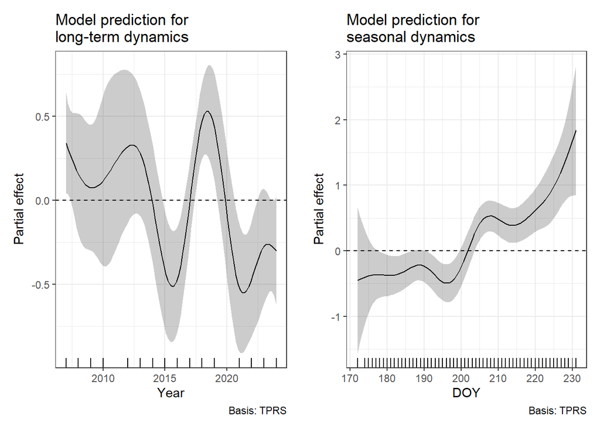

На этих рисунках, как и везде, горизонтальная пунктирная линия отражает среднее по популяции значение. Ниже нуля - меньше среднего и наоборот.

С сезонной динамикой все более или менее понятно. К концу лета голодных становится больше. Биология мне непонятна: все съели? Нерест? Уже нагуляли жир и больше не надо? Пищевые объекты мигрировали? И т.д.

С многолетней динамикой сложнее. С динамикой размеров это, скорее всего, не связано, так как нет связи частоты пустых с размером, который был включен в модель. То есть было два нажористых периода, когда частота пустых была ниже среднего.

## Динамика веса пищевого комка в заполненных желудках

Анализируем общий вес пищи в желудках

Модель, котрую строим имеет следующий вид

Total_Weight ~ s(Year) + s(DOY) + s(L)

Вот результаты подбора модели

```
##
## Family: gaussian
## Link function: identity
##
## Formula:
## Total_Weight ~ s(Year) + s(DOY) + s(L, k = 5)
##
## Parametric coefficients:
##             Estimate Std. Error t value Pr(>|t|)
## (Intercept)   8.5773     0.2249   38.14   <2e-16 ***
## ---
## Signif. codes:  0 '***' 0.001 '**' 0.01 '*' 0.05 '.' 0.1 ' ' 1
##
## Approximate significance of smooth terms:
##           edf Ref.df      F  p-value
## s(Year) 6.630  7.694  5.141 3.84e-06 ***
## s(DOY)  1.631  2.042  0.938    0.387
## s(L)    3.816  3.979 40.743  < 2e-16 ***
## ---
## Signif. codes:  0 '***' 0.001 '**' 0.01 '*' 0.05 '.' 0.1 ' ' 1
##
## R-sq.(adj) =  0.117   Deviance explained = 12.4%
## GCV = 76.975  Scale est. = 76.308    n = 1509
```

Выявляется многолетняя динамика и, естественно, связь с размером. Сезонной динамики не выявляется.

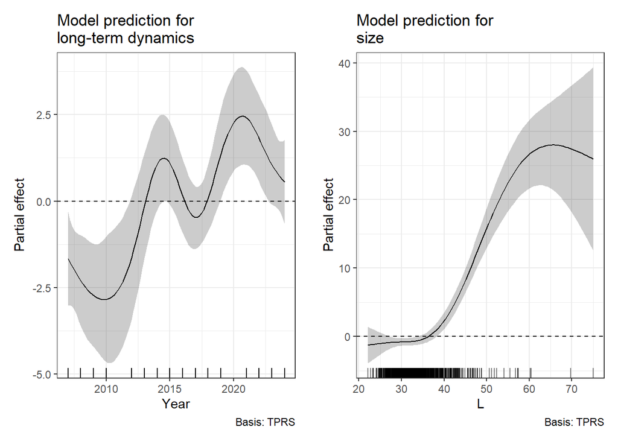

В принципе, хорошо видно, что общее количество еды в желудках было максимальным, в те годы, когда была минимальная доля пустых. Так что, скорее всего, это про голодные и сытые годы. При этом видно, что после где-то 2015 года кормовая база стала сильно лучше. Ну а связь с размером очевидна.

## Состав пищевого комка

Вот таблица со средними весами видов в отдельные годы. Не уверен, что в статью такая нужна (может быть в ESM)

| Year | G.aculeatus | C.pallasii_marisalbi | P.gunnelus | M.scorpuis_ | G.morhua_marisalbi | A.marinus | C.lumpus | Fish_eggs | Lumpenus_sp. | Limanda_limanda | Agonus_cataphractus | Mallotus_villosus | Pisces_Rest | S.boreas | E.gaimardii | P.montagui | A.nugax | R.aculeata | P.pubescens | S.septemcarinata | Mysidacea | P.propinguus | P.annulicornis | Crustacea_Rest | O.aculeata | O.robusta | H.araneus | Nereis_sp. | Thyonidium_pellucidum |
| --- | --- | --- | --- | --- | --- | --- | --- | --- | --- | --- | --- | --- | --- | --- | --- | --- | --- | --- | --- | --- | --- | --- | --- | --- | --- | --- | --- | --- | --- |
| 2007 | 2.21 | 0.16 | 0.31 | 0.06 | 0.58 | 0.10 | 0.01 | 0.30 | 0.32 | 0.06 | 0.00 | 0.00 | 0.08 | 0.03 | 0.02 | 0.00 | 0.00 | 0.02 | 0.00 | 0.00 | 0.00 | 0 | 0.01 | 0.00 | 0.10 | 0.00 | 0.02 | 0.25 | 0.01 |
| 2008 | 2.15 | 0.70 | 0.23 | 0.08 | 0.00 | 0.05 | 0.00 | 0.77 | 0.10 | 0.00 | 0.00 | 0.00 | 0.28 | 0.07 | 0.02 | 0.07 | 0.00 | 0.00 | 0.07 | 0.08 | 0.00 | 0 | 0.00 | 0.00 | 0.00 | 0.00 | 0.00 | 0.27 | 0.00 |
| 2009 | 1.82 | 0.76 | 0.48 | 0.28 | 0.08 | 0.00 | 0.00 | 0.62 | 0.12 | 0.00 | 0.00 | 0.00 | 0.16 | 0.06 | 0.01 | 0.02 | 0.04 | 0.00 | 0.02 | 0.00 | 0.00 | 0 | 0.00 | 0.08 | 0.03 | 0.00 | 0.03 | 0.24 | 0.00 |
| 2010 | 1.77 | 0.36 | 0.51 | 0.00 | 0.00 | 0.00 | 0.00 | 0.10 | 0.08 | 0.00 | 0.00 | 0.00 | 0.00 | 0.00 | 0.03 | 0.00 | 0.00 | 0.00 | 0.00 | 0.00 | 0.00 | 0 | 0.00 | 0.05 | 0.69 | 0.15 | 0.00 | 0.18 | 0.00 |
| 2012 | 2.94 | 1.14 | 0.00 | 0.16 | 0.00 | 0.00 | 0.00 | 0.35 | 0.24 | 0.39 | 0.00 | 0.00 | 0.00 | 0.00 | 0.00 | 0.00 | 0.00 | 0.00 | 0.00 | 0.00 | 0.00 | 0 | 0.00 | 0.00 | 0.41 | 0.10 | 0.00 | 0.00 | 0.00 |
| 2013 | 2.81 | 0.84 | 0.13 | 0.50 | 0.12 | 0.00 | 0.00 | 0.56 | 0.22 | 0.00 | 0.00 | 0.00 | 0.06 | 0.16 | 0.01 | 0.00 | 0.00 | 0.00 | 0.00 | 0.00 | 0.00 | 0 | 0.00 | 0.00 | 0.00 | 0.04 | 0.00 | 0.22 | 0.00 |
| 2014 | 2.45 | 0.89 | 0.08 | 0.00 | 1.06 | 0.42 | 0.00 | 0.82 | 0.39 | 0.14 | 0.28 | 0.56 | 0.97 | 0.00 | 0.01 | 0.00 | 0.00 | 0.00 | 0.00 | 0.00 | 0.00 | 0 | 0.00 | 0.00 | 0.20 | 0.00 | 0.00 | 0.18 | 0.00 |
| 2015 | 2.50 | 0.03 | 0.09 | 0.00 | 0.00 | 0.36 | 0.00 | 2.47 | 0.16 | 0.00 | 0.00 | 0.41 | 0.30 | 0.52 | 0.02 | 0.00 | 0.00 | 0.00 | 0.00 | 0.00 | 0.00 | 0 | 0.00 | 0.00 | 0.14 | 0.00 | 0.00 | 1.49 | 0.00 |
| 2016 | 3.60 | 0.00 | 0.00 | 0.00 | 0.00 | 0.00 | 0.00 | 1.09 | 0.00 | 0.00 | 0.00 | 0.00 | 0.00 | 0.00 | 0.01 | 0.00 | 0.01 | 0.00 | 0.00 | 0.00 | 0.00 | 0 | 0.00 | 0.00 | 0.00 | 0.00 | 0.00 | 1.37 | 0.00 |
| 2017 | 1.91 | 0.21 | 0.12 | 0.06 | 0.06 | 1.25 | 0.00 | 0.96 | 0.11 | 0.00 | 0.00 | 0.00 | 0.06 | 0.00 | 0.01 | 0.00 | 0.01 | 0.00 | 0.00 | 0.00 | 0.00 | 0 | 0.00 | 0.01 | 0.21 | 0.02 | 0.00 | 0.99 | 0.00 |
| 2018 | 1.85 | 0.73 | 0.00 | 0.00 | 0.00 | 0.42 | 0.00 | 1.17 | 0.00 | 0.00 | 0.00 | 0.23 | 0.02 | 0.05 | 0.02 | 0.00 | 0.01 | 0.00 | 0.00 | 0.00 | 0.00 | 0 | 0.00 | 0.00 | 0.13 | 0.01 | 0.00 | 0.69 | 0.00 |
| 2019 | 3.03 | 2.03 | 0.05 | 0.40 | 0.36 | 0.05 | 0.00 | 0.70 | 0.00 | 0.00 | 0.00 | 0.00 | 0.00 | 0.35 | 0.03 | 0.00 | 0.04 | 0.00 | 0.00 | 0.00 | 0.08 | 0 | 0.00 | 0.00 | 0.02 | 0.00 | 0.00 | 0.69 | 0.00 |
| 2021 | 1.80 | 4.45 | 0.16 | 0.17 | 0.00 | 0.00 | 0.00 | 0.88 | 1.21 | 0.13 | 0.00 | 0.28 | 0.26 | 0.11 | 0.01 | 0.00 | 0.01 | 0.02 | 0.00 | 0.00 | 0.00 | 0 | 0.00 | 0.00 | 0.04 | 0.00 | 0.00 | 0.31 | 0.00 |
| 2022 | 2.07 | 2.00 | 0.00 | 0.21 | 1.14 | 0.00 | 0.00 | 0.11 | 0.41 | 0.09 | 0.00 | 0.00 | 0.02 | 0.05 | 0.00 | 0.00 | 0.00 | 0.00 | 0.00 | 0.00 | 0.00 | 0 | 0.00 | 0.00 | 0.35 | 0.01 | 0.00 | 0.26 | 0.00 |
| 2023 | 2.51 | 0.88 | 0.00 | 0.16 | 0.33 | 0.00 | 0.00 | 1.20 | 0.50 | 0.10 | 0.00 | 0.00 | 0.06 | 0.04 | 0.00 | 0.00 | 0.00 | 0.00 | 0.00 | 0.00 | 0.00 | 0 | 0.00 | 0.00 | 0.67 | 0.01 | 0.00 | 1.36 | 0.00 |
| 2024 | 2.09 | 0.81 | 0.00 | 0.00 | 0.08 | 0.02 | 0.00 | 1.43 | 0.19 | 0.04 | 0.00 | 0.00 | 0.09 | 0.13 | 0.02 | 0.01 | 0.01 | 0.00 | 0.00 | 0.00 | 0.00 | 0 | 0.00 | 0.00 | 0.11 | 0.01 | 0.13 | 1.87 | 0.00 |

Вот средние веса пищевых объектов (в сумме за все годы по тем рыбам, у которых что-то было в желудке)

| Species | Mean_Weigt | SD |
| --- | --- | --- |
| G.aculeatus | 2.2 | 4.65 |
| C.pallasii_marisalbi | 0.9 | 5.26 |
| Fish_eggs | 0.9 | 3.18 |
| Nereis_sp. | 0.8 | 2.70 |
| A.marinus | 0.3 | 2.83 |
| G.morhua_marisalbi | 0.2 | 2.29 |
| Lumpenus_sp. | 0.2 | 1.82 |
| O.aculeata | 0.2 | 0.95 |
| P.gunnelus | 0.1 | 1.17 |
| M.scorpuis_ | 0.1 | 1.21 |
| Mallotus_villosus | 0.1 | 1.82 |
| Pisces_Rest | 0.1 | 1.21 |
| S.boreas | 0.1 | 1.00 |
| C.lumpus | 0.0 | 0.07 |
| Limanda_limanda | 0.0 | 0.52 |
| Agonus_cataphractus | 0.0 | 0.45 |
| E.gaimardii | 0.0 | 0.11 |
| P.montagui | 0.0 | 0.09 |
| A.nugax | 0.0 | 0.10 |
| R.aculeata | 0.0 | 0.07 |
| P.pubescens | 0.0 | 0.08 |
| S.septemcarinata | 0.0 | 0.11 |
| Mysidacea | 0.0 | 0.11 |
| P.propinguus | 0.0 | 0.01 |
| P.annulicornis | 0.0 | 0.02 |
| Crustacea_Rest | 0.0 | 0.10 |
| O.robusta | 0.0 | 0.20 |
| H.araneus | 0.0 | 0.69 |
| Thyonidium_pellucidum | 0.0 | 0.05 |

## Динамика видового разнообразия пищевого спектра

Для каждого года посчитан коэффициент видового разнообразия Шеннона.

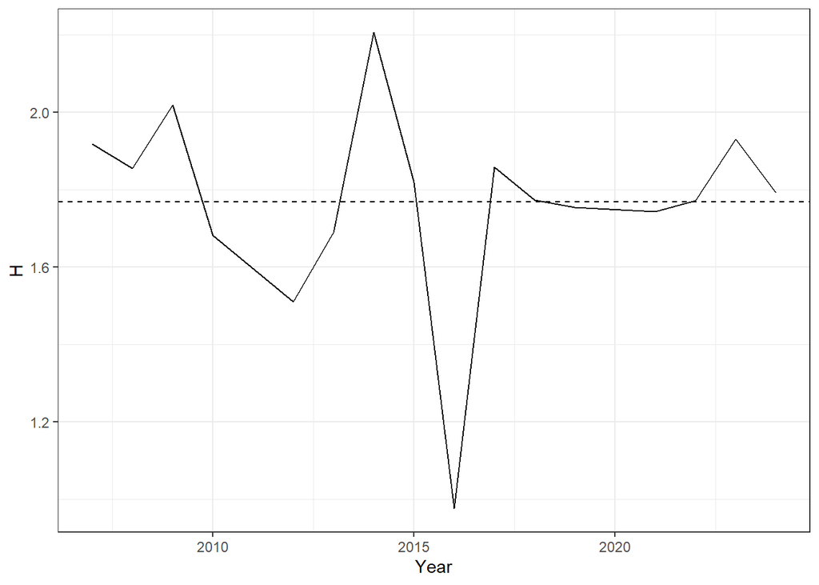

Поскольку для коэффициента Шеннона я не могу придумать как правильно посчитать доверительную область, то имеет смысл обсуждать лишь резкий провал в разнообразии после 2015 г. В этот год жрали какой-то ограниченный набор пищевых объектов.

## Динамика обилия видов

Предлагаю далее работать с пятеркой самых обильных пищевых объектов.

Для построения модели будем брать логарифмы весов.

Модель будет вот такая

log(Weight+1) ~ s(Year, by = Species) + s(DOY, by = Species) + s(L, by = Species) + Species

Во результаты этой модели.

```
##
## Family: gaussian
## Link function: identity
##
## Formula:
## log(Weight + 1) ~ s(Year, by = Species) + s(DOY, by = Species) +
##     s(L, by = Species, k = 5) + Species
##
## Parametric coefficients:
##                             Estimate Std. Error t value Pr(>|t|)
## (Intercept)                  0.87153    0.01760   49.53   <2e-16 ***
## SpeciesC.pallasii_marisalbi -0.70002    0.02489  -28.13   <2e-16 ***
## SpeciesA.marinus            -0.79747    0.02489  -32.04   <2e-16 ***
## SpeciesFish_eggs            -0.54106    0.02489  -21.74   <2e-16 ***
## SpeciesNereis_sp.           -0.53854    0.02489  -21.64   <2e-16 ***
## ---
## Signif. codes:  0 '***' 0.001 '**' 0.01 '*' 0.05 '.' 0.1 ' ' 1
##
## Approximate significance of smooth terms:
##                                       edf Ref.df      F  p-value
## s(Year):SpeciesG.aculeatus          5.379  6.447  2.109 0.044610 *
## s(Year):SpeciesC.pallasii_marisalbi 8.043  8.733  8.786  < 2e-16 ***
## s(Year):SpeciesA.marinus            5.567  6.645  4.548 7.89e-05 ***
## s(Year):SpeciesFish_eggs            7.858  8.628  4.672 3.62e-06 ***
## s(Year):SpeciesNereis_sp.           6.011  7.097 12.902  < 2e-16 ***
## s(DOY):SpeciesG.aculeatus           7.423  8.332 30.098  < 2e-16 ***
## s(DOY):SpeciesC.pallasii_marisalbi  1.327  1.587 13.586 0.000120 ***
## s(DOY):SpeciesA.marinus             2.598  3.273 10.980 4.74e-07 ***
## s(DOY):SpeciesFish_eggs             4.920  6.001 17.288  < 2e-16 ***
## s(DOY):SpeciesNereis_sp.            5.736  6.853  9.509  < 2e-16 ***
## s(L):SpeciesG.aculeatus             3.862  3.988 49.493  < 2e-16 ***
## s(L):SpeciesC.pallasii_marisalbi    1.000  1.000 11.084 0.000875 ***
## s(L):SpeciesA.marinus               1.936  2.426  1.563 0.255238
## s(L):SpeciesFish_eggs               3.130  3.618 16.118  < 2e-16 ***
## s(L):SpeciesNereis_sp.              1.794  2.252  5.617 0.002834 **
## ---
## Signif. codes:  0 '***' 0.001 '**' 0.01 '*' 0.05 '.' 0.1 ' ' 1
##
## R-sq.(adj) =  0.231   Deviance explained = 23.8%
## GCV = 0.47178  Scale est. = 0.4673    n = 7545
```

Почти у всех видов есть как сезонная, так и многолетняя динамика. Размеры рыб тоже имеют значение (за исключением A.marinus).

Вот визуализации многолетней динамики

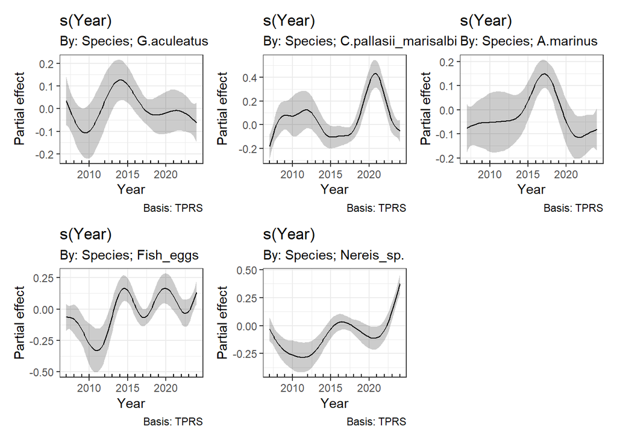

Тут я пока ничего сказать не могу кроме того, что ест явные изменения структуры рациона. Наример, сперва наедались колюшками, потом A.marinus, а потом селедкам, а в конце перешли на нереисов.

Вот визуализации сезонной динамики

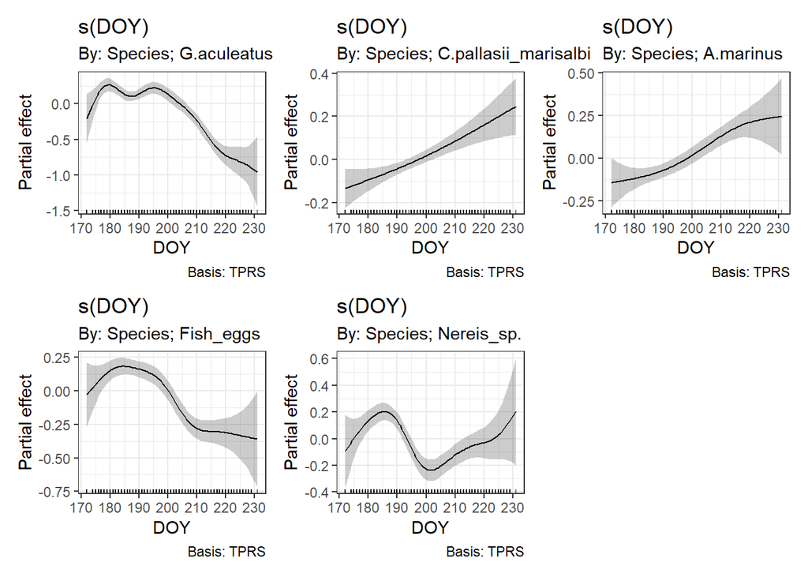

Здесь все более логично. Сперва едят колюшку и, я полагаю, ее яйца, пока она не свалила в море. Потом переходят на селедку и A.marinus. Нереиса, я думаю, жрут в период его хода, который как раз в начале лета.

Вот связь с размерами.

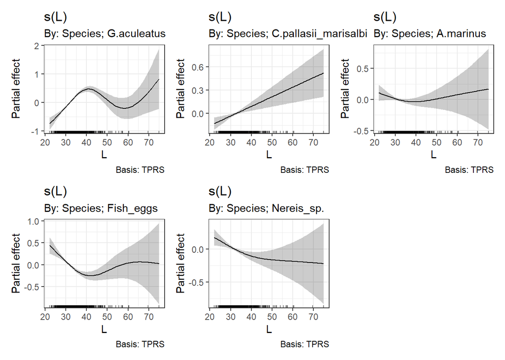

Нереисов и рыбью икру едят мелкие, селедку и колюшку больше едят более крупные.